# Are June hot days becoming more common, and do they coincide with rain?

## Chart

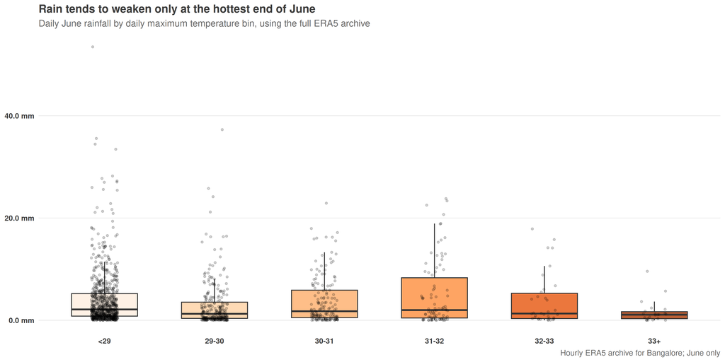

```r
chart_path <- file.path(chart_dir, "june-hot-days-rain.png")

p <- june_daily %>%
  mutate(temp_bin = cut(
    tmax,
    breaks = c(-Inf, 29, 30, 31, 32, 33, Inf),
    labels = c("<29", "29-30", "30-31", "31-32", "32-33", "33+")
  )) %>%
  ggplot(aes(temp_bin, rain_mm, fill = temp_bin)) +
  geom_boxplot(outlier.shape = NA, alpha = 0.8, width = 0.6) +
  geom_jitter(width = 0.12, alpha = 0.18, size = 1.0) +
  scale_y_continuous(labels = label_number(accuracy = 0.1, suffix = " mm")) +
  scale_fill_brewer(palette = "Oranges") +
  labs(
    title = "Rain tends to weaken only at the hottest end of June",
    subtitle = "Daily June rainfall by daily maximum temperature bin, using the full ERA5 archive",
    caption = "Hourly ERA5 archive for Bangalore; June only"
  ) +
  theme_weather_question()

p
```

```r
ggsave(chart_path, p, width = 12, height = 6, dpi = 180, bg = "white")
```

## Checks

```r
base_june %>%
  summarise(
    mean_tmax = mean(tmax),
    p90_tmax = quantile(tmax, 0.9),
    p95_tmax = quantile(tmax, 0.95),
    hot31_days_per_june = mean(tmax >= 31),
    hot32_days_per_june = mean(tmax >= 32),
    hot33_days_per_june = mean(tmax >= 33),
    rain_correlation = cor(tmax, rain_mm, use = "complete.obs")
  )
```

```
##   mean_tmax p90_tmax p95_tmax hot31_days_per_june hot32_days_per_june
## 1  28.69293    31.04  31.8065           0.1059259          0.04222222
##   hot33_days_per_june rain_correlation
## 1           0.0162963       -0.1844497
```

## Verdict

Insightful: no

This is a useful descriptive check, but not strong enough to publish. The archive says June hot days are uncommon overall, and the rain relationship is real but modest rather than dramatic. The best takeaway is that Bangalore can have warm-and-wet June days, but the truly hottest June days are comparatively rare and a bit drier.

Charts:

- `docs/assets/analysis/june-hot-days-rain.png`

Blog post:

- not published